# Praca domowa 3

Piotr Miziński

26 października 2018

## Pierwotny wykres

Wykres, który postanowiono poprawić podczas tej pracy domowej znaleziono na stronie https://krknews.pl/malopolska-pis-wygra-wybory-do-sejmiku-ale-nie-bedzie-rzadzil/. Dotyczy on podziału mandatów do Sejmiku Województwa Małopolskiego, który nastapił podczas tegorocznych wyborów. Pokazano go poniżej.

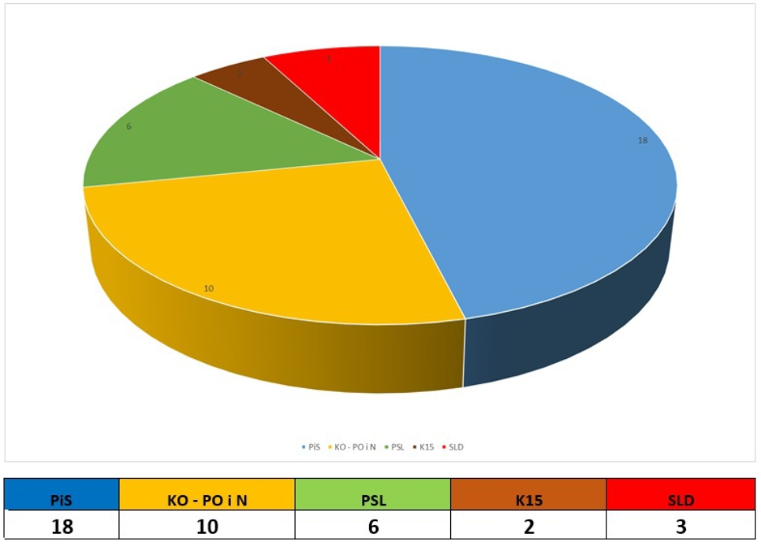

- PiS wybory wygrywa zdecydowanie, ale nie jest w stanie sam rządzić w Małopolsce. Zdobywa tutaj 18 mandatów, a więc musi stworzyć koalicję, aby uzyskać większość.
- Jeżeli powstanie koalicja “antyPiS”, wówczas to ona przejmie władze w Małopolsce.

## Poprawiony wykres

Oprócz użycia wykresu kołowego, co samo w sobie jest złem wizualiazacji danych, pokazano również tabelkę przekazującą te same dane - po co więc umieszczać wykres kołowy skoro dokładnych danych procentowych i tak nie można z niego odczytać? W związku z tym, zdecydowano się stworzyć wykres słupkowy, na którym pokazano liczbę otrzymanych mandatów przez daną partię polityczną oraz umieszczono informację o procentowej ich liczbie względem całości. Wykres umieszczono poniżej.

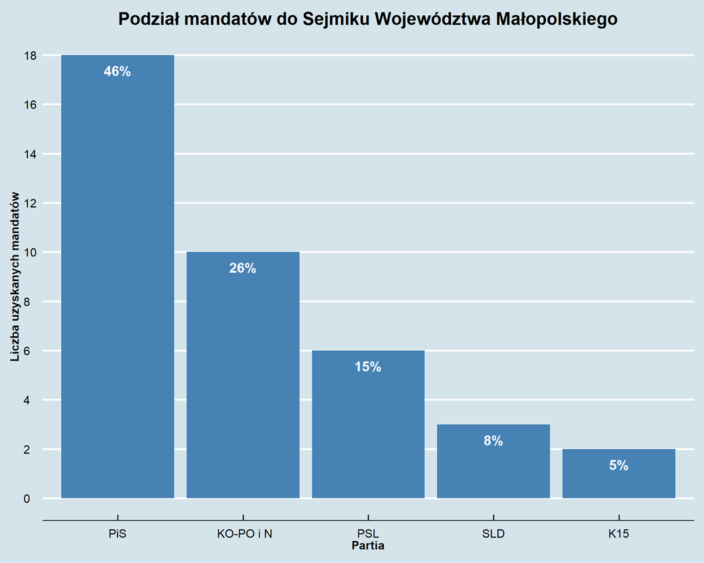

```r
ggplot(data = dane, aes(x=reorder(partia, -mandaty), y=mandaty)) +
  geom_bar(stat="identity", fill="steelblue")+
  theme_economist(base_size = 12)+
  geom_text(aes(label = paste0(round(100*mandaty/sum(mandaty)), "%")), stat = "identity",
            vjust = 2,colour='white',size=5,fontface=2)+
  scale_y_continuous(breaks=seq(0,20,2))+
  labs(title="Podział mandatów do Sejmiku Województwa Małopolskiego",
       x="Partia", y = "Liczba uzyskanych mandatów", size = 10)+
  theme(axis.text=element_text(size=12),
       axis.title=element_text(size=12,face="bold"),
       plot.title = element_text(hjust = 0.5))
```